# Graphically Based Data Analysis Using Flexplot

Dustin Fife

1  
fife.dustin@gmail.com

# Introduction

In light of the recent “replication crisis” (Pashler and Wagenmakers 2012; Open Science Collaboration 2015), researchers are becoming increasingly concerned with the validity of science (Baker 2016). As such, many are pushing for greater transparency and reproducibility (Nelson, Simmons, and Simonsohn 2018; Nosek et al. 2018). One way to accomplish greater transparency is through abudant use of data visualizations (Tay et al. 2016), particularly when data are presented in their raw form.

In addition to answering the call for greater transparency, graphics offer several additional advantages. First, they improve communication between the scientific community and the public. Lay people can understand relatively sophisticated statistical procedures when that information is presented graphically (Correll 2015). Additionally, graphics highlight problems with models that are masked by traditional statistical procedures, such as nonlinearity, outliers, heteroscedasticity, etc. As such, graphics serve as an important diagnostic check. Finally, graphics improve encoding. Consider the image displayed in Figure 1, taken from Correll (2015). The table on the left presents the same information as the one on the right, though the encoding of the information on the right is much easier because that information is conveyed *visually.*

[figure not shown]

While visualizations have many advantages, they can also be used to mislead, sometimes intentionally, and sometimes not intentionally. For example, when means/standard errors are presented as barcharts, people tend to judge values below the mean (i.e., within the confines of the bar) as far more likely than values above the mean, even when the underlying distribution is symmetric (Correll 2015). Unfortunately, aesthetics are often conflated with informativeness, and people often convince themselves they are learning something important from poor graphics (Padilla et al. 2015). To further complicate matters, the default images in most point-and-click statistical software violate important visualization heuristics (Fife 2019). For example, in SPSS it is impossible (as far as I know) to produce standard error plots that display raw data (jittered or otherwise). Also, with standard error plots, the axes are scaled to the means, not the range of the actual data, which visually inflates the size of the effect. In addition, producing some types of graphics (e.g., Skew-Location plots) require more effort than many are willing to perform (the user must model the data, export the residuals, jitter the residuals, then produce a scatterplot).

Flexplot was designed to address these limitations. Flexplot was developed using empirically-derived heurstics that maximize perceptual understanding, while minimizing perceptual biases. Also, the graphics produced are simple to generate and permit analysts to quickly shift between statistical modeling and graphical interpretation.

# Guiding Philosophy of Flexplot

The design of Flexplot is based on the following principles:

*1. Minimize obstacles to producing graphics.* The easier it is to produce graphics, the more likely graphics will be used, and the more resources the researcher will have available to interpret the data. Technology companies like Apple and Google spend millions of dollars attempting to make the interaction between humans and technology as seamless as possible. One-click purchasing, voice-activated personal assistants like Siri, movies-on-demand, and audible app notifications are all tricks companies use to remove obstacles to using their technology. Likewise, if producing a graphic is as simple (or simpler) than performing a statistical analysis, they too will become heavily utilized (and, dare I say, addictive?). Furthermore, the less effort required to produce graphics, the more resources available to invest in *interpreting* graphics. To make producing graphics as simple as possible, Flexplot makes many of the plotting decisions in the background, such as choosing between types of graphics (e.g., histograms versus bar charts) and how those graphics are displayed.

*2. Design graphics that leverage human strenths and mitigate human biases.* Successful technology capitalizes on human strengths. A mobile phone, for example, leverages humanity’s advanced finger tactile sensitivity and dexterity. A phone designed to be used by one’s foot would be a very poor choice indeed. Likewise, a computer that sends olefactory information might work well for a dog, but not a human. Graphics technology ought to be designed with the same principles in mind. Unfortunately, standard statistical analyses do not capitalize on human strengths. It takes a great deal of training to understand even basic statistics, and even then results are frequently misinterpreted. To overcome this limitation, some of the tools within Flexplot create visual representation of the statistical models. These representations highlight uncertainty, reveal whether chosen models are appropriate, and improve encoding of statistical information.

# A New Grammar of Graphics

Hadley Wickham, the author of `ggplot2`, developed a “layered” grammar of graphics (Wickham 2010). Wickham’s grammar allows a great deal flexibility in the design of graphics. However, this flexibility comes at cost. Very often the grammar necessary to produce a graphic requires a great deal of coding to produce. For example, consider the code to create jittered mean plots:

```r
plot = ggplot(data=exercise_data, aes(x=therapy.type, y=weight.loss)) +
  geom_jitter(amount=.2, alpha=.4) +
  stat_summary(fun.y='mean', geom='point',
               size=3, position=position_dodge(width=.2)) +
  stat_summary(geom='errorbar', fun.ymin = function(z){mean(z)-1.96*sd(z)},
               fun.ymax=function(z) {mean(z)+1.96*sd(z)},
               size=1.25, width=.2, position=position_dodge(width=.2))
```

As noted earlier, the more difficult it is to produce a graphic, the more likely it is someone will simply not use it. A similar graphic can be produced with only one line of code using the `flexplot()` function:

```r
plot = flexplot(weight.loss~therapy.type, data=exercise_data)
```

Naturally, this simplicity comes at a cost; Flexplot is more limited than ggplot2. However, Flexplot will cover the majority of graphics analysts will use for statistical modeling. However, in the end, graphics produced through Flexplot are still `ggplot2` objects. As such, they can be edited and/or layered for further customization.

The base `plot()` function in R follows similar conventions to Flexplot (i.e., users can specify an equation, such as `plot(y~x)`), though `flexplot()` is more intelligent in its choices of displays. Also, `plot()` only allows the user to visualize one variable at a time. Another function, `coplot()`, allows some multivariate visualizations, yet it is limited in the types of data allowed and, like `plot()` isn’t flexible in the types of visualization decisions it makes. The Flexplot package, on the other hand, offers great flexibility and automates much of the decision-making.

In the following section, I will demonstrate how decisions are made in Flexplot. I begin by showing how to produce univariate graphics, then bivariate graphics, then multivariate graphics. I will then follow that up with various functions and techniques for combining visuals with models, then conclude with a brief summary.

# Univariate Graphics

In `lm()`, one can model an “intercept only” model, using the code `lm(y~1)`. This is equivalent to estimating the mean of $y$. Flexplot follows a similar convention with visualizing univariate distributions. However, the type of graphic displayed depends on the type of variable inputted into the function. For example, in the code below, notice that `flexplot()` recognizes whether the variable is categorical or numeric, and plots accordingly.

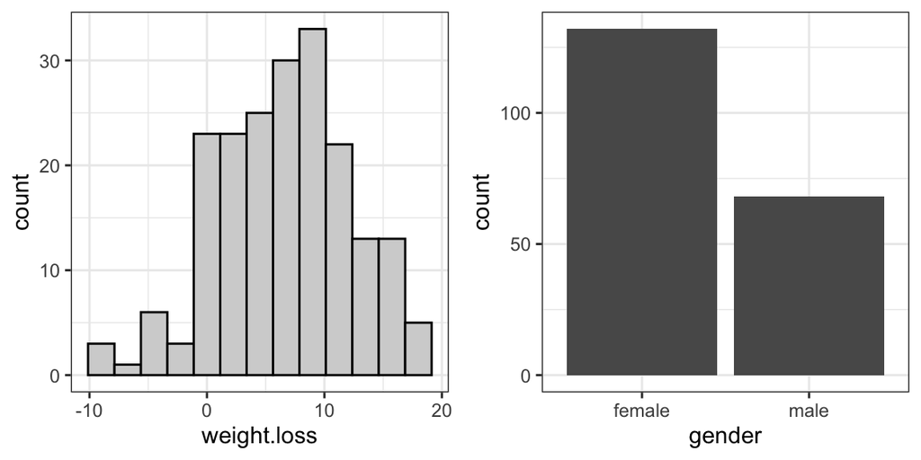

Figure 2: A histogram (left) and barchart (right) produced by `flexplot()`.

```r
require(flexplot)
data(exercise_data)
a = flexplot(weight.loss~1, data=exercise_data)
b = flexplot(gender~1, data=exercise_data)
cowplot::plot_grid(a,b)
```

Sometimes, `flexplot()` will make a wrong guess, if, for example, a categorical variable is recorded as a number (e.g., 1=Group 1, 2= Group 2, 3 = Group 3). To force `flexplot()` to produce a barchart, simply convert the variable to a factor (e.g., `data$group = factor(data$group, levels=1:3, labels=c("Group1", "Group2", "Group3"))`).

# Bivariate Graphics

As with univariate graphics, Flexplot will automatically produce an appropriate graphic, depending on the type of predictors variable (PV) and outcome variable (OV): numeric PV/numeric OV will produce a scatterplot, numeric PV/categorical OV = logistic curve graph, categorical PV/numeric OV = jittered density plot, and categorical PV/categorical OV = bar chart.

## Categorical Predictor, Numeric Outcome (Jittered-Density Plots)

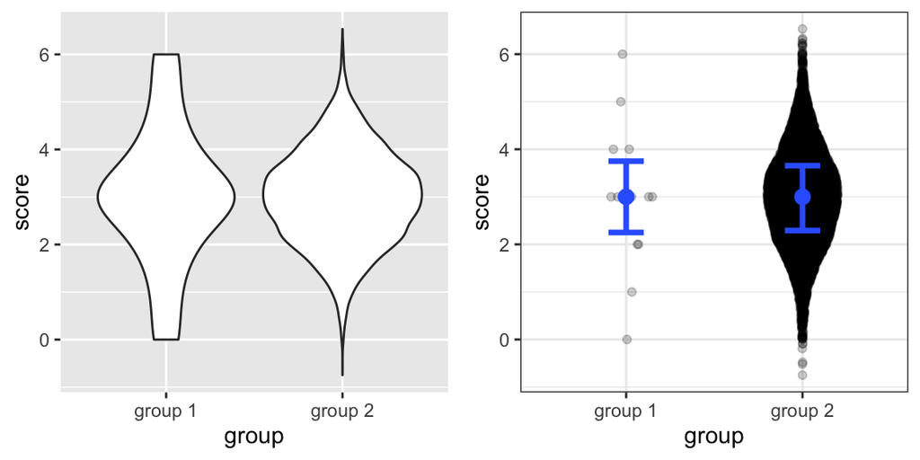

```r
#### generate data for two groups with unequal sample sizes,
#### but the same distribution

group1 = c(0,1,2,2,3,3,3,3,3,3,4,4,5,6)
group2 = rnorm(10000,3,1)

d = data.frame(score=c(group1, group2),
               group=c(rep("group 1", times=length(group1)),
                       rep("group 2", times=length(group2))))
a = ggplot2::ggplot(data=d, aes(x=group, y=score)) +  geom_violin()

b = flexplot(score~group, data=d)
cowplot::plot_grid(a,b)
```

In `flexplot()`, one can control the amount of jittering. The amount of jittering can be specified in multiple ways: as a boolean (`TRUE` means it will jitter, `FALSE` it won’t), as a number (e.g., `0.2`), or as a vector (e.g., `c(.2, .4)`, which will indicate .2 jittering for X and .4 for Y). Just as it is in `geom_jitter()`, this number refers to the amount of jittering on either side. However, the value refers to the *maximum* amount the computer will jitter the data. So, 0.2 (the default) will jitter 10% of the way to the right only at the highest density and 10% to the left at the highest density.

Users can also specify what the “whiskers” mean for the summary statistics. They default to the interquartile range (with the median as the center dot), but the user can also specify `sterr`, or `stdev,` to indicate the standard error or standard deviation:

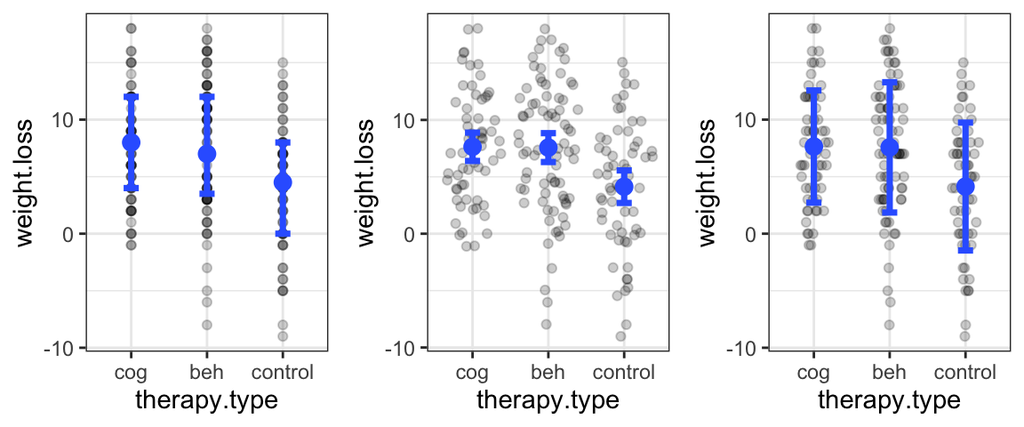

Figure 4: Dot plots with IQR and no jittering (left), JD plot with mean + standard errors + jittering on $X$ and $Y$ (middle), and JD plot with mean + standard deviation with jittering on only $X$ (right), as well as different forms of jittering.

```r
data("exercise_data")
a = flexplot(weight.loss~therapy.type, data=exercise_data,
             jitter=F, spread="quartile")
b = flexplot(weight.loss~therapy.type, data=exercise_data,
             jitter=c(.4,.5), spread="sterr")
c = flexplot(weight.loss~therapy.type, data=exercise_data,
             jitter=.2, spread="stdev")
cowplot::plot_grid(a,b,c, nrow=1)
```